# Video Session Assignment 3: Vietnam and Sweden

Andre Neveu

10/26/2020

# Empirical Project 5 Working in R

These code downloads have been constructed as supplements to the full Doing Economics projects (https://core-econ.org/doing-economics/). You’ll need to download the data before running the code that follows.

## Getting started in R

For this project you will need the following packages:

- `tidyverse`, to help with data manipulation
- `readxl`, to import an Excel spreadsheet
- `ineq`, to calculate inequality measures
- `reshape2`, to rearrange a dataframe.

If you need to install any of these packages, run the following code:

```r
#you just have to run this install once, and do not have to do it when you "knit". I recommend changing the line above from {r} to {r, eval=FALSE} to prevent evaluation of this chunk
install.packages(c(
  "tidyverse",
  "ineq", "reshape2"))
```

You can import these libraries now, or when they are used in the R walk-throughs below.

```r
#to exclude the messages that R produces, put the code ", message=FALSE, warning=FALSE" in the start of the chunk. This still executes (evaluates) the code. If you wanted to block this out entirely, you would also put ",echo=FALSE" in the top of the chunk
library(readxl)
library(tidyverse)
library(ineq)
library(reshape2)
```

## Part 5.1 Measuring income inequality

### R walk-through 5.1 Importing an Excel file (either `.xlsx` or .`xls` format) into R

As we are importing an Excel file, we use the `read_excel` function from the `readxl` package. The file is called `GCIPrawdata.xlsx`. Before you import the file into R, open the datafile in Excel to understand its structure. You will see that the data is all in one worksheet (which is convenient), and that the headings for the variables are in the third row. Hence we will use the `skip = 2` option in the `read_excel` function to skip the first two rows.

```r
decile_data <- read_excel("GCIPrawdata.xlsx", skip = 2)
```

The data is now in a “tibble” (like a spreadsheet for R). Let’s use the `head` function to look at the first few rows:

```r
head(decile_data)
```

```
## # A tibble: 6 x 14
##   Country  Year `Decile 1 Incom~ `Decile 2 Incom~ `Decile 3 Incom~
##   <chr>   <dbl>            <dbl>            <dbl>            <dbl>
## 1 Afghan~  1980              206              350              455
## 2 Afghan~  1981              212              361              469
## 3 Afghan~  1982              221              377              490
## 4 Afghan~  1983              238              405              527
## 5 Afghan~  1984              249              424              551
## 6 Afghan~  1985              256              435              566
## # ... with 9 more variables: `Decile 4 Income` <dbl>, `Decile 5 Income` <dbl>,
## #   `Decile 6 Income` <dbl>, `Decile 7 Income` <dbl>, `Decile 8 Income` <dbl>,
## #   `Decile 9 Income` <dbl>, `Decile 10 Income` <dbl>, `Mean Income` <dbl>,
## #   Population <dbl>
```

As you can see, each row shows data for a different country-year combination. The first row is for Afghanistan in 1980, and the first value (in the third column) is 206, for the variable `Decile 1 Income`. This value indicates that the mean annual income of the poorest 10% in Afghanistan was the equivalent of 206 USD (in 1980, adjusted using purchasing power parity). Looking at the next column, you can see that the mean income of the next richest 10% (those in the 11th to 20th percentiles for income) was 350.

To see the list of variables, we use the `str` function.

```r
str(decile_data)
```

```
## tibble [4,799 x 14] (S3: tbl_df/tbl/data.frame)
##  $ Country         : chr [1:4799] "Afghanistan" "Afghanistan" "Afghanistan" "Afghanistan" ...
##  $ Year            : num [1:4799] 1980 1981 1982 1983 1984 ...
##  $ Decile 1 Income : num [1:4799] 206 212 221 238 249 256 268 243 223 202 ...
##  $ Decile 2 Income : num [1:4799] 350 361 377 405 424 435 457 414 380 344 ...
##  $ Decile 3 Income : num [1:4799] 455 469 490 527 551 566 594 539 493 447 ...
##  $ Decile 4 Income : num [1:4799] 556 574 599 644 674 692 726 659 603 547 ...
##  $ Decile 5 Income : num [1:4799] 665 686 716 771 806 828 869 788 722 654 ...
##  $ Decile 6 Income : num [1:4799] 793 818 854 919 961 ...
##  $ Decile 7 Income : num [1:4799] 955 986 1029 1107 1157 ...
##  $ Decile 8 Income : num [1:4799] 1187 1225 1278 1376 1438 ...
##  $ Decile 9 Income : num [1:4799] 1594 1645 1717 1848 1932 ...
##  $ Decile 10 Income: num [1:4799] 3542 3655 3814 4105 4291 ...
##  $ Mean Income     : num [1:4799] 1030 1063 1109 1194 1248 ...
##  $ Population      : num [1:4799] 13211412 12996923 12667001 12279095 11912510 ...
```

In addition to the country, year, and the ten income deciles, we have mean income and the population.

[End of walk-through]

### R walk-through 5.2 Calculating cumulative shares using the `cumsum` function

Here we have chosen Vietnam (a country that recently underwent enormous economic changes) and the Sweden (a developed country). We use the `subset` function to create a new dataset (called `temp`) containing only the countries and years we need.

```r
#  Select the data for the chosen country and years
sel_Year <- c(1980, 2014)
sel_Country <- c("Vietnam", "Sweden")

temp <- subset(
  decile_data,
  (decile_data$Country %in% sel_Country) &
  (decile_data$Year %in% sel_Year))
temp
```

```
## # A tibble: 4 x 14
##   Country  Year `Decile 1 Incom~ `Decile 2 Incom~ `Decile 3 Incom~
##   <chr>   <dbl>            <dbl>            <dbl>            <dbl>
## 1 Sweden   1980             3389             4973             6068
## 2 Sweden   2014             5465             8252            10220
## 3 Vietnam  1980               90              130              173
## 4 Vietnam  2014              374              698              991
## # ... with 9 more variables: `Decile 4 Income` <dbl>, `Decile 5 Income` <dbl>,
## #   `Decile 6 Income` <dbl>, `Decile 7 Income` <dbl>, `Decile 8 Income` <dbl>,
## #   `Decile 9 Income` <dbl>, `Decile 10 Income` <dbl>, `Mean Income` <dbl>,
## #   Population <dbl>
```

Before we calculate cumulative income shares, we need to calculate the total income for each country-year combination using the mean income and the population size.

```r
print("Total incomes are:")
```

```
## [1] "Total incomes are:"
```

```r
total_income <- temp[, "Mean Income"] *
  temp[, "Population"]
total_income
```

```
##    Mean Income
## 1  72318240762
## 2 151670604415
## 3  27225900000
## 4 269649560000
```

These numbers are very large, so for our purpose it is easier to assume that there is only one person in each decile, in other words the total income is 10 times the mean income. This simplification works because, by definition, each decile has exactly the same number of people (10% of the population).

We will be using the very useful `cumsum` function (short for “cumulative sum”) to calculate the cumulative income. To see what this function does, look at this simple example.

```r
test <- c(2, 4, 10, 22)
cumsum(test)
```

```
## [1]  2  6 16 38
```

```r
# Pick the deciles (Columns 3 to 12) in Row 1 (Sweden, 1980)
decs_c80 <- unlist(temp[1, 3:12])

# The unlist function transforms temp[1, 3:12] from a
# tibble to simple vector with data which simplifies the
# calculations.

# Give the total income, assuming a population of 10
total_inc <- 10 * unlist(temp[1, "Mean Income"])

cum_inc_share_c80 = cumsum(decs_c80) / total_inc
cum_inc_share_c80
```

```
##  Decile 1 Income  Decile 2 Income  Decile 3 Income  Decile 4 Income
##       0.03894507       0.09609285       0.16582395       0.24587451
##  Decile 5 Income  Decile 6 Income  Decile 7 Income  Decile 8 Income
##       0.33541715       0.43450931       0.54416226       0.66695013
##  Decile 9 Income Decile 10 Income
##       0.80940014       0.99998851
```

```r
# For Sweden, 2014
# Go to Row 2 (Sweden, 2014)
decs_c14 <- unlist(temp[2, 3:12])

# Give the total income, assuming a population of 10
total_inc <- 10 * unlist(temp[2, "Mean Income"])

cum_inc_share_c14 = cumsum(decs_c14) / total_inc
cum_inc_share_c14
```

```
##  Decile 1 Income  Decile 2 Income  Decile 3 Income  Decile 4 Income
##       0.03491344       0.08763176       0.15292276       0.22866543
##  Decile 5 Income  Decile 6 Income  Decile 7 Income  Decile 8 Income
##       0.31412509       0.40950616       0.51606721       0.63693861
##  Decile 9 Income Decile 10 Income
##       0.78054686       0.99997445
```

```r
# For the Vietnam, 1980
# Select Row 3 (Vietnam, 1980)
decs_us80 <- unlist(temp[3, 3:12])

# Give the total income, assuming a population of 10
total_inc <- 10 * unlist(temp[3, "Mean Income"])

cum_inc_share_us80 = cumsum(decs_us80) / total_inc

# For the Vietnam, 2014
# Select Row 4 (Vietnam, 2014)
decs_us14 <- unlist(temp[4, 3:12])

# Give the total income, assuming a population of 10
total_inc <- 10 * unlist(temp[4, "Mean Income"])

cum_inc_share_us14 = cumsum(decs_us14) / total_inc
```

[End of walk-through]

### R walk-through 5.3 Drawing Lorenz curves

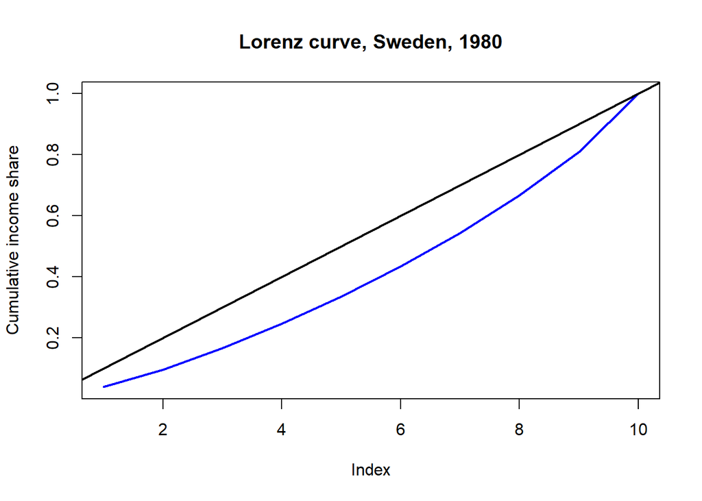

```r
plot(cum_inc_share_c80, type = "l", col = "blue",
  lwd = 2, ylab = "Cumulative income share")

# Add the perfect equality line
abline(a = 0, b = 0.1, col = "black", lwd = 2)

title("Lorenz curve, Sweden, 1980")
```

The blue line is the Lorenz curve. The Gini coefficient is the ratio of the area between the two lines and the total area under the black line. We will calculate the Gini coefficient in R walk-through 5.4.

Now we add the other Lorenz curves to the chart using the `lines` function. We use the `col=` option to specify a different colour for each line, and the `lty` option to make the line pattern solid for 2014 data and dashed for 1980 data. Finally, we use the `legend` function to add a chart legend in the top left corner of the chart.

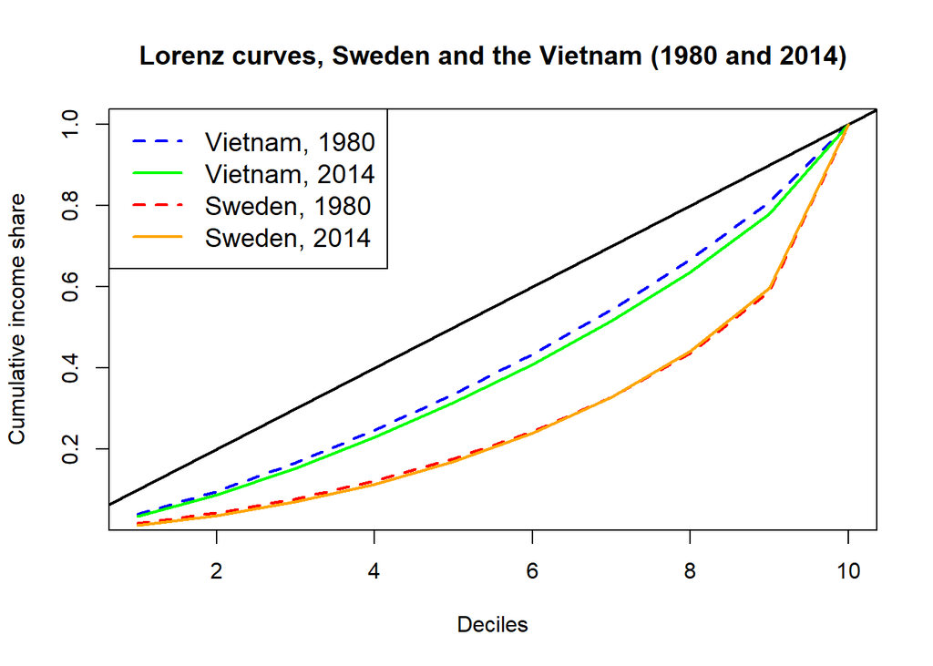

```r
plot(cum_inc_share_c80, type = "l", col = "blue",
  lty = 2, lwd = 2, xlab = "Deciles",
  ylab = "Cumulative income share")

# Add the perfect equality line
abline(a = 0, b = 0.1, col = "black", lwd = 2)

# lty = 1 = dashed line
lines(cum_inc_share_c14, col = "green", lty = 1, lwd = 2)

# lty = 2 = solid line
lines(cum_inc_share_us80, col = "red", lty = 2, lwd = 2)

lines(cum_inc_share_us14, col = "orange",
  lty = 1, lwd = 2)

title("Lorenz curves, Sweden and the Vietnam (1980 and 2014)")

legend("topleft", lty = 2:1, lwd = 2, cex = 1.2, legend =
  c("Vietnam, 1980", "Vietnam, 2014",
    "Sweden, 1980", "Sweden, 2014"),
  col = c("blue", "green", "red", "orange"))
```

[End of walk-through]

### R walk-through 5.4 Calculating Gini coefficients

```r
# Load the ineq library
library(ineq)

# The decile mean incomes from R walk-through 5.3 are used.
g_c80 <- Gini(decs_c80)
g_c14 <- Gini(decs_c14)
g_us80 <- Gini(decs_us80)
g_us14 <- Gini(decs_us14)
paste("Gini coefficients")
```

```
## [1] "Gini coefficients"
```

[output not shown]

```r
paste("Vietnam - 1980: ", round(g_c80, 2),
  ", 2014: ", round(g_c14, 2))
```

```
## [1] "Vietnam - 1980:  0.23 , 2014:  0.27"
```

[output not shown]

```r
paste("Sweden - 1980: ", round(g_us80, 2),
  ", 2014: ", round(g_us14, 2))
```

```
## [1] "Sweden - 1980:  0.49 , 2014:  0.5"
```

[output not shown]

Now we make the same line chart (simply copy and paste the code from R walk-through 5.3, but use the `text` function to label curves with their respective Gini coefficients. The two numbers in the `text` function specify the coordinates (horizontal and vertical) where the text should be written (experiment for yourself to find the best place to put the labels), and we used the `round` function to show the first three digits of the calculated Gini coefficients.

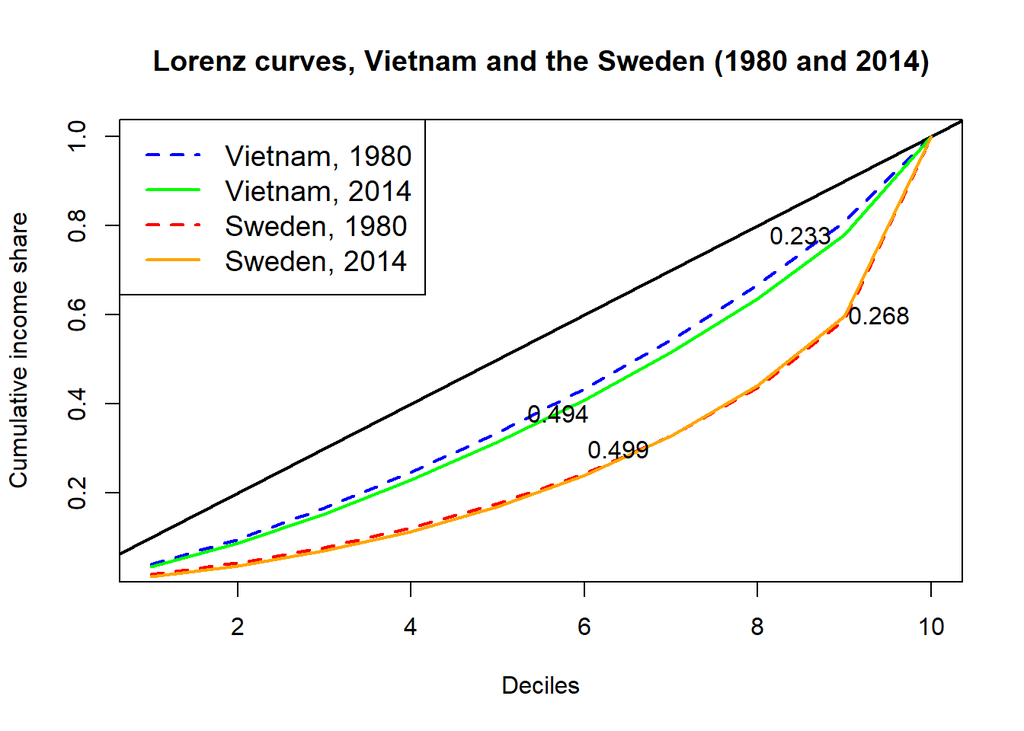

```r
plot(cum_inc_share_c80, type = "l", col = "blue", lty = 2,
  lwd = 2, xlab = "Deciles",
  ylab = "Cumulative income share")

# Add the perfect equality line
abline(a = 0, b = 0.1, col = "black", lwd = 2)

# lty = 1 = dashed line
lines(cum_inc_share_c14, col = "green", lty = 1, lwd = 2)

# lty = 2 = solid line
lines(cum_inc_share_us80, col = "red", lty = 2, lwd = 2)

lines(cum_inc_share_us14, col = "orange", lty = 1, lwd = 2)

title("Lorenz curves, Vietnam and the Sweden (1980 and 2014)")

legend("topleft", lty = 2:1, lwd = 2, cex = 1.2, legend =
  c("Vietnam, 1980", "Vietnam, 2014",
    "Sweden, 1980", "Sweden, 2014"),
  col = c("blue", "green", "red", "orange"))

text(8.5, 0.78, round(g_c80, digits = 3))
text(9.4, 0.6, round(g_c14, digits = 3))
text(5.7, 0.38, round(g_us80, digits = 3))
text(6.4, 0.3, round(g_us14, digits = 3))
```

The Gini coefficients for both countries have increased, confirming what we already saw from the Lorenz curves that in both countries the income distribution has become more unequal.

[End of walk-through]

### Extension R walk-through 5.5 Calculating Gini coefficients for all countries and all years using a loop

In this extension walk-through, we show you how to calculate the Gini coefficient for all countries and years in your dataset.

This sounds like a tedious task, and indeed if we were to use the same method as before it would be mind-numbing. However, we have a powerful programming language at hand, and this is the time to use it.

Here we use a very useful programming tool you may not have come across yet: loops. Loops are used to repeat a specified block of code. There are a few types of loop, and here we will use a “for” loop, meaning that we ask R to apply the same code to each number or item in a specific list (i.e. repeat the code ‘for’ a list of numbers/items). Let’s start with a very simple case: printing the first 10 square numbers. In coding terms, we are printing the values for `i^2` for the numbers `i=1, ..., 10`.

```r
for (i in seq(1, 10)){
  print(i^2)
}
```

```
## [1] 1
## [1] 4
## [1] 9
## [1] 16
## [1] 25
## [1] 36
## [1] 49
## [1] 64
## [1] 81
## [1] 100
```

In the above command, `seq(1, 10)` creates a vector of numbers from 1 to 10 (1, 2, 3, …, 10). The command `for (i in seq(1, 10))` defines the variable `i` initially as 1, then performs all the commands that are between the curly brackets for each value of `i` (typically these commands will involve the variable `i`). Here our command prints the value of `i^2` for each value of `i`. Check that you understand the syntax above by modifying it to print only the first 5 square numbers, or adding 2 to the numbers from 1 to 10 (instead of squaring these numbers).

Now we use loops to complete our task. We begin by creating a new variable in our dataset, `gini`, which we initially set to 0 for all country-year combinations.

```r
decile_data$gini <- 0
```

Now we use a loop to run through all the rows in our dataset (country-year combinations). For each row we will repeat the Gini coefficient calculation from R walk-through 5.4 and save the resulting value in the `gini` variable we created.

```r
# Give us the number of rows in decile_data
noc <- nrow(decile_data)

for (i in seq(1, noc)){
  # Go to Row I to get the decile data
  decs_i <- unlist(decile_data[i, 3:12])
  decile_data$gini[i] <- Gini(decs_i)
}
```

With this code, we calculated 4,799 Gini coefficients without having to manually run the same command 4,799 times. We now look at some summary measures for the `gini` variable.

```r
summary(decile_data$gini)
```

```
##    Min. 1st Qu.  Median    Mean 3rd Qu.    Max.
##  0.1791  0.3470  0.4814  0.4617  0.5700  0.7386
```

The average Gini coefficient is 0.46, the maximum is 0.74, and the minimum 0.18. Let’s look at these extreme cases.

First we will look at the extremely equal income distributions (those with a Gini coefficient smaller than 0.20):

```r
temp <- subset(
  decile_data, decile_data$gini < 0.20,
  select = c("Country", "Year", "gini"))
temp
```

```
## # A tibble: 17 x 3
##    Country          Year  gini
##    <chr>           <dbl> <dbl>
##  1 Bulgaria         1987 0.191
##  2 Czech Republic   1985 0.195
##  3 Czech Republic   1986 0.194
##  4 Czech Republic   1987 0.192
##  5 Czech Republic   1988 0.191
##  6 Czech Republic   1989 0.194
##  7 Czech Republic   1990 0.196
##  8 Czech Republic   1991 0.199
##  9 Slovak Republic  1985 0.195
## 10 Slovak Republic  1986 0.194
## 11 Slovak Republic  1987 0.193
## 12 Slovak Republic  1988 0.192
## 13 Slovak Republic  1989 0.193
## 14 Slovak Republic  1990 0.194
## 15 Slovak Republic  1991 0.195
## 16 Slovak Republic  1992 0.196
## 17 Slovak Republic  1993 0.179
```

These correspond to eastern European countries before the fall of communism.

Now the most unequal countries (those with a Gini coefficient larger than 0.73):

```r
temp <- subset(
  decile_data, decile_data$gini > 0.73,
  select = c("Country", "Year", "gini"))
temp
```

```
## # A tibble: 27 x 3
##    Country       Year  gini
##    <chr>        <dbl> <dbl>
##  1 Burkina Faso  1980 0.738
##  2 Burkina Faso  1981 0.738
##  3 Burkina Faso  1982 0.738
##  4 Burkina Faso  1983 0.738
##  5 Burkina Faso  1984 0.738
##  6 Burkina Faso  1985 0.738
##  7 Burkina Faso  1986 0.738
##  8 Burkina Faso  1987 0.738
##  9 Burkina Faso  1988 0.738
## 10 Burkina Faso  1989 0.739
## # ... with 17 more rows
```

[End of walk-through]

### Extension R walk-through 5.6 Plotting time series of Gini coefficients, using ggplot

In this extension walk-through, we show you how to make time series plots (time on the horizontal axis, the variable of interest on the vertical axis) with Gini coefficients for a list of countries of your choice.

There are many ways to plot data in R, one being the standard plotting function (`plot`) we used in previous walk-throughs. Another (and perhaps more beautiful) way is to use the `ggplot` function, which is part of the `tidyverse` package we loaded earlier. Our dataset is already in a format which the `ggplot` function can easily use (the “long” format, where each row corresponds to a different country-year combination).

First we use the `subset` function to select a small list of countries and save their data as `temp_data`. As an example, we have chosen four anglophone countries: the UK, the US, Ireland, and Australia.

```r
temp_data <- subset(
  decile_data, Country %in% c("United Kingdom",
    "United States", "Ireland", "Australia"))
```

Now we plot the data using `ggplot`.

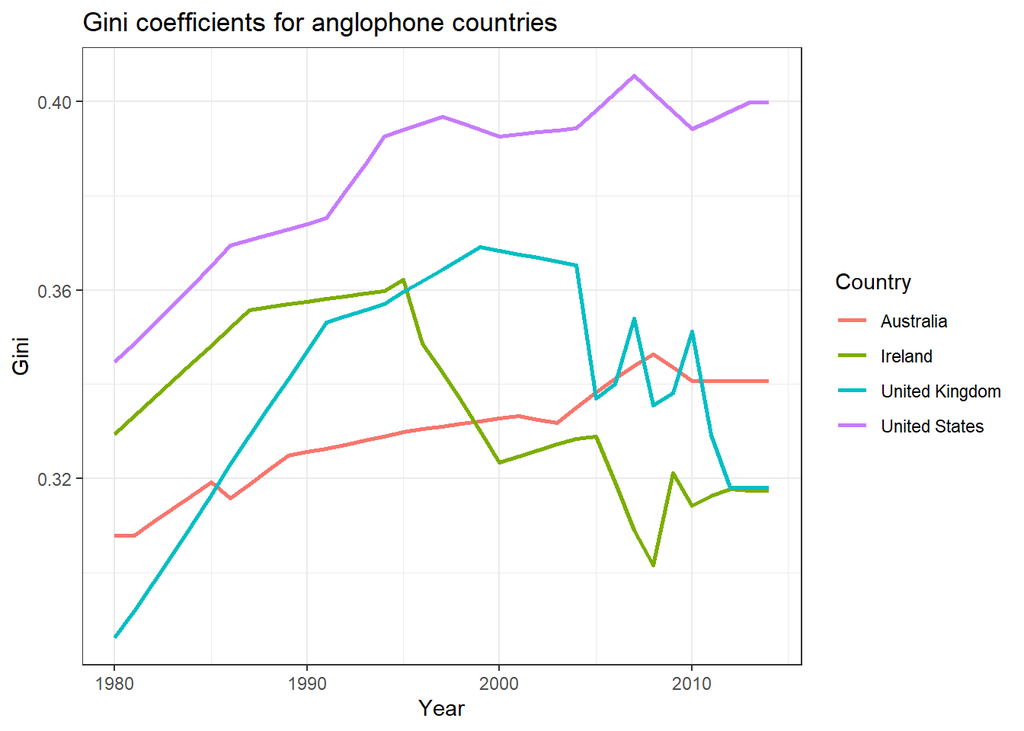

```r
ggplot(temp_data,
  aes(x = Year, y = gini, color = Country)) +
  geom_line(size = 1) +
  theme_bw() +
  ylab("Gini") +
  # Add a title
  ggtitle("Gini coefficients for anglophone countries")
```

We asked the `ggplot` function to use the `temp_data` dataframe, with `Year` on the horizontal axis (`x =`) and `gini` on the vertical axis (`y =`). The `color` option indicates which variable we use to separate the data (use a different line for each unique item in `Country`). The first line of code sets up the chart, and the `+ geom_line(size = 1)` then instructs R to draw lines. (See what happens if you replace `+ geom_line(size = 1)` with `+ geom_point(size = 1)`.)

`ggplot` assumes that the different lines you want to show are identified through the different values in one variable (here, the `Country` variable). If your data is formatted differently, for example, if you have one variable for the Gini of each country (“wide” format), then in order to use `ggplot` you will first have to transform the dataset into “long” format. Doing so is beyond the scope of this task, however you can find a worked example online, such as ‘R TSplots’ (https://tinyco.re/5093147).[^1] Project 4 also explains how to transform data between “wide” and “long” formats.

The `ggplot` package is extremely powerful, and if you want to produce a variety of different charts, you may want to read more about that package, for example, see a Harvard R tutorial (https://tinyco.re/8185055) or an R statistics tutorial (https://tinyco.re/9652072) for great examples that include code.

[End of walk-through]

## Part 5.2 Measuring other kinds of inequality

### R walk-through 5.7 Importing `.csv` files into R

Before importing, make sure the .csv file is saved in your working directory. After importing (using the `read.csv` function), use the `str` function to check that the data was imported correctly.

```r
# Open the csv file from the working directory
health_in <- read.csv("inequality-of-life-as-measured-by-mortality-gini-coefficient-1742-2002.csv")
str(health_in)
```

```
## 'data.frame':    320 obs. of  4 variables:
##  $ Entity    : chr  "Brazil" "Brazil" "Brazil" "Brazil" ...
##  $ Code      : chr  "BRA" "BRA" "BRA" "BRA" ...
##  $ Year      : int  1892 1897 1902 1907 1912 1917 1922 1927 1932 1937 ...
##  $ X.percent.: num  0.566 0.557 0.547 0.482 0.494 ...
```

The variable `Entity` is the country and the variable `X.percent` is the health Gini. Let’s change these variable names (to `Country` and `Health`, respectively) to clarify what they actually refer to, which will help when writing code (and if we go back to read this code at a later date).

```r
# Country is the first variable.
names(health_in)[1] <- "Country"
# Health Gini is the fourth variable.
names(health_in)[4] <- "HGini"
```

```r
levels(health_in$Code)[levels(health_in$Code) == ""] <-
  "ENW"
```

[End of walk-through]

### R walk-through 5.8 Creating line graphs with `ggplot`

As shown in R walk-through 5.7, the data is already formatted so that we can use `ggplot` directly (in “long” format), in other words we have only one variable for the mortality Gini (`HGini`), and we can separate the data by country using one variable (`Country`).

Most of the code below is similar to our use of `ggplot` in previous walk-throughs, though this time we added the option `labs` to change the vertical axis label (`y =`) and the option `scale_color_brewer` to change the colour palette (to clearly differentiate the lines for each country).

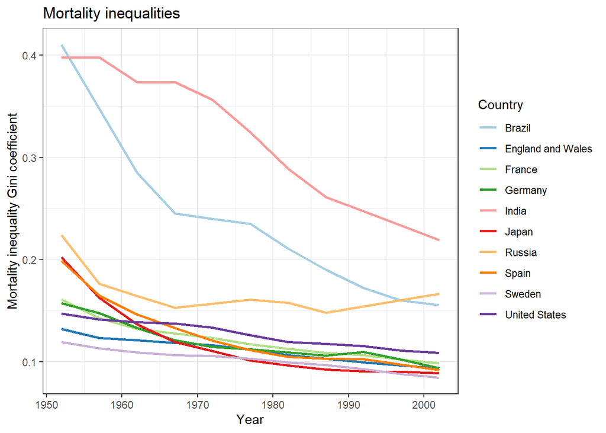

```r
# Select all data after 1951
temp_data <- subset(health_in, Year > 1951)

ggplot(temp_data,
  aes(x = Year, y = HGini, color = Country)) +
  geom_line(size = 1) +
  labs(y = "Mortality inequality Gini coefficient") +
  # Change the colour palette
  scale_color_brewer(palette = "Paired") +
  theme_bw() +
  # Add a title
  ggtitle("Mortality inequalities")
```

[End of walk-through]

### R walk-through 5.9 Drawing a column chart with sorted values

#### Plot a column chart for 1952

First we use `subset` to extract the data for 1952 only, and store it in a temporary dataset (`tempdata`).

```r
# Select all data for 1952
temp_data <- subset(health_in, Year == 1952)

# Reorder rows in temp_data by the values of HGini
temp_data <- temp_data[order(temp_data$HGini), ]
temp_data
```

```
##               Country Code Year     HGini
## 279            Sweden  SWE 1952 0.1194045
## 46  England and Wales      1952 0.1319542
## 310     United States  USA 1952 0.1471329
## 138           Germany  DEU 1952 0.1572112
## 86             France  FRA 1952 0.1605238
## 228             Spain  ESP 1952 0.1985371
## 184             Japan  JPN 1952 0.2021728
## 206            Russia  RUS 1952 0.2237161
## 161             India  IND 1952 0.3978703
## 13             Brazil  BRA 1952 0.4103805
```

The rows are now ordered according to `HGini`, in ascending order. Let’s use `ggplot` again.

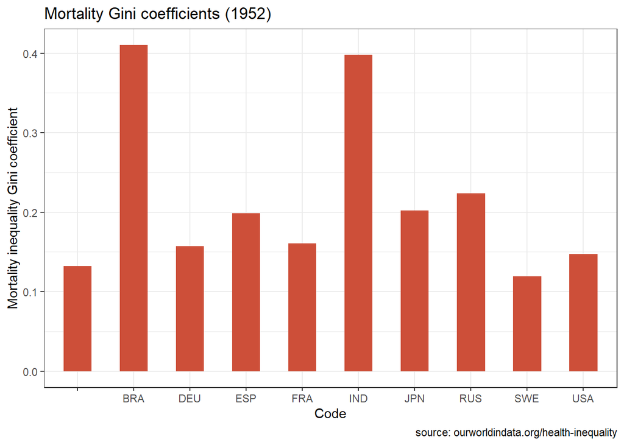

```r
ggplot(temp_data, aes(x = Code, y = HGini)) +
  geom_bar(stat = "identity", width = .5,
    fill = "tomato3") +
  theme_bw() +
  labs(title = "Mortality Gini coefficients (1952)",
    caption =
      "source: ourworldindata.org/health-inequality",
    y = "Mortality inequality Gini coefficient")
```

```r
levels(temp_data$Code)
```

[output not shown]

A blog post (http://tinyco.re/1992106) from *Data Se* provides the following code for “R geom_bar change order”, and uses the `reorder` function to reorder the horizontal axis variable (`Code`) according to the `HGini` value.

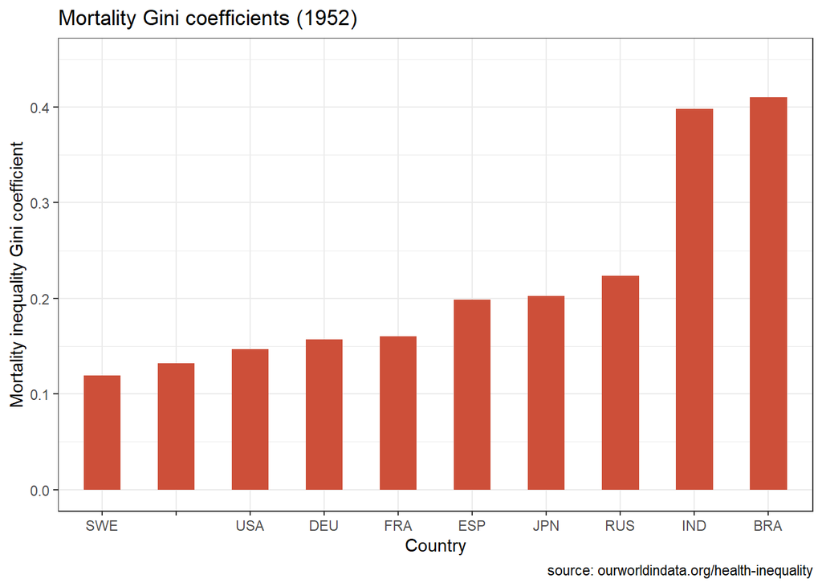

```r
ggplot(temp_data,
  aes(x = reorder(Code, HGini), y = HGini)) +
  geom_bar(stat = "identity", width = .5,
    fill = "tomato3") +
  coord_cartesian(ylim = c(0, 0.45)) +
  theme_bw() +
  labs(title = "Mortality Gini coefficients (1952)",
    x = "Country",
    caption =
      "source: ourworldindata.org/health-inequality",
    y = "Mortality inequality Gini coefficient")
```

#### Plot a column chart for 2002

We want to compare this ranking with the ranking of 2002. First we extract the relevant data again.

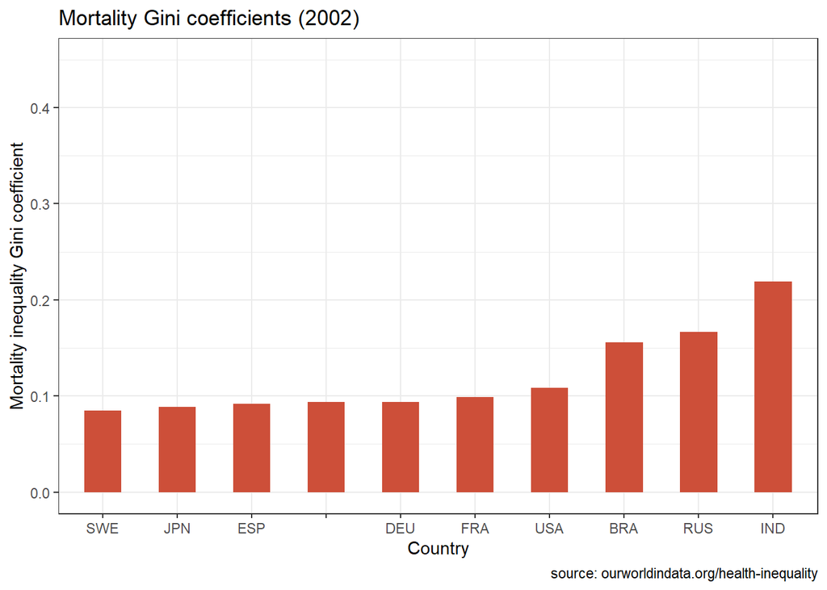

```r
# Select all data for 2002
temp_data <- subset(health_in, Year == 2002)

ggplot(temp_data,
  aes(x = reorder(Code, HGini), y = HGini)) +
  geom_bar(stat = "identity", width = .5,
    ylim = c(0, 0.45), fill = "tomato3") +
  # Adjust vertical axis scale for comparability with 1952
  coord_cartesian(ylim = c(0, 0.45)) +
  theme_bw() +
  labs(title = "Mortality Gini coefficients (2002)",
    x = "Country",
    caption =
      "source: ourworldindata.org/health-inequality",
    y = "Mortality inequality Gini coefficient")
```

It is fairly easy to plot the data for both years in the same chart, by extracting both years into the same temporary dataset.

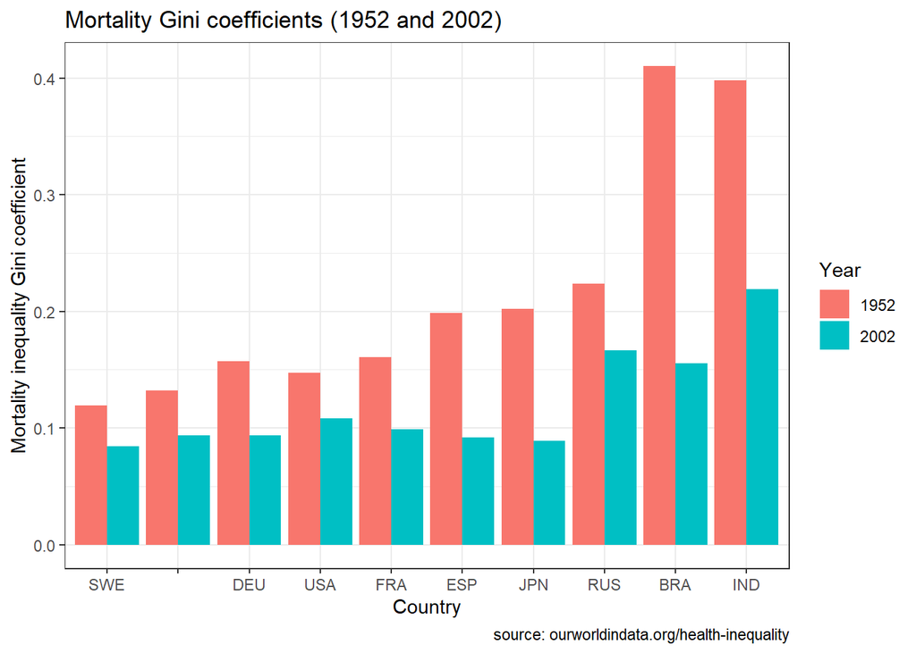

```r
# Select all data for 1952 and 2002
temp_data <- subset(health_in, Year %in% c("1952", "2002"))
temp_data$Year <- factor(temp_data$Year)

ggplot(temp_data,
  aes(x = reorder(Code, HGini), y = HGini, fill = Year)) +
  geom_bar(position="dodge", stat = "identity") +
  theme_bw() +
  labs(
    title = "Mortality Gini coefficients (1952 and 2002)",
    x = "Country",
    caption =
      "source: ourworldindata.org/health-inequality",
    y = "Mortality inequality Gini coefficient")
```

Now the country ordering is in terms of the average HGini, rather than HGini in 1952 (which might have made comparisons easier).

[End of walk-through]

### R walk-through 5.10 Drawing a column chart with sorted values

For this walk-through, we downloaded the ‘access to essential medicines’ data, as explained above. Here we saved it as `WHO access to essential medicines.csv`. Looking at the spreadsheet in Excel, you can see that the actual data starts in row three, meaning there are two header rows. So let’s `skip` the first row when uploading it.

```r
med_access <- read.csv("WHO access to essential medicines.csv", skip = 1)
str(med_access)
```

```
## 'data.frame':    38 obs. of  3 variables:
##  $ Country     : chr  "Afghanistan" "Bahamas" "Bolivia (Plurinational State of)" "Brazil" ...
##  $ X2007.2013  : num  94 42.9 86.7 76.7 72.1 58.3 13.3 90.7 31.3 33.3 ...
##  $ X2007.2013.1: num  81.1 43.2 31.9 0 87.1 46.7 15.5 86.7 21.2 100 ...
```

Let’s change the names of these variables (to `Private_Access` and `Public_Access` respectively) to make working with them easier:

```r
names(med_access)[2] <- "Private_Access"
names(med_access)[3] <- "Public_Access"
```

To find details about these variables, click the “Metadata” button on the website to find the following explanation (under “Method of measurement”):

A standard methodology has been developed by WHO and Health Action International (HAI). Data on the availability of a specific list of medicines are collected in at least four geographic or administrative areas in a sample of medicine dispensing points. Availability is reported as the percentage of medicine outlets where a medicine was found on the day of the survey.

Before we produce charts of the data, we shall look at some summary measures of the access variable (`med_access`).

```r
summary(med_access)
```

```
##    Country          Private_Access   Public_Access
##  Length:38          Min.   :  2.80   Min.   :  0.00
##  Class :character   1st Qu.: 54.62   1st Qu.: 39.67
##  Mode  :character   Median : 70.15   Median : 55.95
##                     Mean   : 65.97   Mean   : 58.25
##                     3rd Qu.: 86.70   3rd Qu.: 82.50
##                     Max.   :100.00   Max.   :100.00
##                                      NA's   :2
```

On average, private sector patients have better access to essential medication.

```r
med_access <- med_access[complete.cases(med_access), ]
```

There are a number of interesting aspects to look at. We shall produce a bar chart comparing the private and public access in countries, ordered according to values of private access (largest to smallest). First, we need to reformat the data into “long” format (so there is a single variable containing all the values we want to plot), then use the `ggplot` function to make the chart.

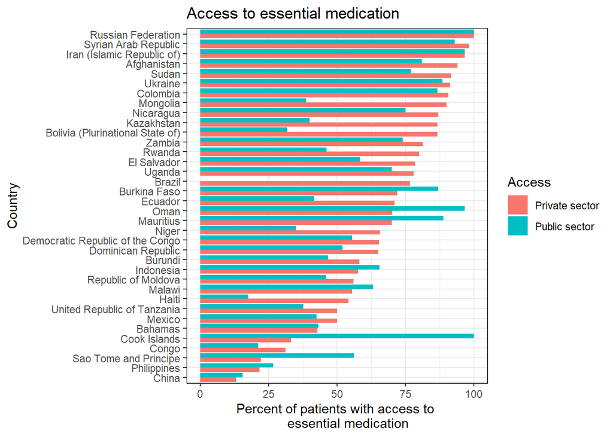

```r
# Reorder by values of private access (largest to smallest)
med_access$Country <- reorder(med_access$Country, med_access$Private_Access)

# This is required for the melt function.
library(reshape2)
# Rearrange the data for ggplot
med_access_melt <- melt(med_access)
# This creates a dataframe with three columns
# Country = Country name
# value = % access (Private_Access or Public_Access).
# variable = indicates Public_Access or Private_Access.

ggplot(med_access_melt,
  aes(x = Country, y = value, fill = variable)) +
  geom_bar(position = "dodge", stat = "identity") +
  scale_fill_discrete(name = "Access",
    labels = c("Private sector", "Public sector")) +
  theme(axis.text.x = element_text(angle = 90,
    hjust = 1, vjust = 0.5)) +
  theme_bw() +
  labs(title = "Access to essential medication",
    x = "Country", y = "Percent of patients with access to
      essential medication") +
  # Flip axis to make country labels readable
  coord_flip()
```

Let’s find the extreme values, starting with the two countries where public sector patients have access to all (100%) essential medications (which you can also see in the chart).

```r
med_access[med_access$Public_Access == 100, ]
```

```
##               Country Private_Access Public_Access
## 10       Cook Islands           33.3           100
## 30 Russian Federation          100.0           100
```

Let’s see which countries provide 0% access to essential medication for people in the public sector.

```r
med_access[med_access$Public_Access == 0, ]
```

```
##   Country Private_Access Public_Access
## 4  Brazil           76.7             0
```

[End of walk-through]

### R walk-through 5.11 Using line and bar charts to illustrate changes in time

#### Import data and plot a line chart

First we import the data into R and check its structure.

```r
# Open the csv file from the working directory
data_prim <- read.csv(
  "OWID-gender-gap-in-primary-education.csv")
str(data_prim)
```

```
## 'data.frame':    9060 obs. of  4 variables:
##  $ Entity                                         : chr  "Afghanistan" "Afghanistan" "Afghanistan" "Afghanistan" ...
##  $ Code                                           : chr  "AFG" "AFG" "AFG" "AFG" ...
##  $ Year                                           : int  1970 1971 1972 1973 1974 1975 1976 1977 1978 1980 ...
##  $ Primary.education..pupils....female.....female.: num  14.1 13.7 14 14.5 14.4 ...
```

The data is now in the dataframe `data_prim`. The variable of interest (`percentage of female enrolment`) has a very long name so we will shorten it to `PFE`.

```r
names(data_prim)[4] <- "PFE"
```

As usual, ensure that you understand the definition of the variables you are using. In the Our World in Data website, look at the “Sources” tab underneath the graph for a definition:

Percentage of female enrollment is calculated by dividing the total number of female students at a given level of education by the total enrolment at the same level, and multiplying by 100.

This definition implies that if the primary-school-age population was 50% male and 50% female and all children were enrolled in school, the percentage of female enrolment would be 50.

Before choosing ten countries, we check which countries (`Entity`) are in the dataset using the `unique` function. Here we also use the `head()` function to only show the first few countries.

```r
head(unique(data_prim$Entity))
```

```
## [1] "Afghanistan"         "Albania"             "Algeria"
## [4] "Andorra"             "Angola"              "Antigua and Barbuda"
```

You can find nearly all the countries in the world in this list (plus some sub- and supra-country entities, like OECD countries, which explains why the variable wasn’t initially called “Country”).

#### Plot a line chart for a selection of countries

We now make a selection of ten countries. (You can of course make a different selection, but ensure that you get the spelling right as R is unforgiving!).

```r
temp_data <- subset(data_prim, Entity %in% c(
  "Albania", "China", "France", "India", "Japan",
  "Switzerland", "United Arab Emirates",
  "United Kingdom", "Zambia", "United States"))
```

Now we plot the data, similar to what we did earlier.

[output not shown]

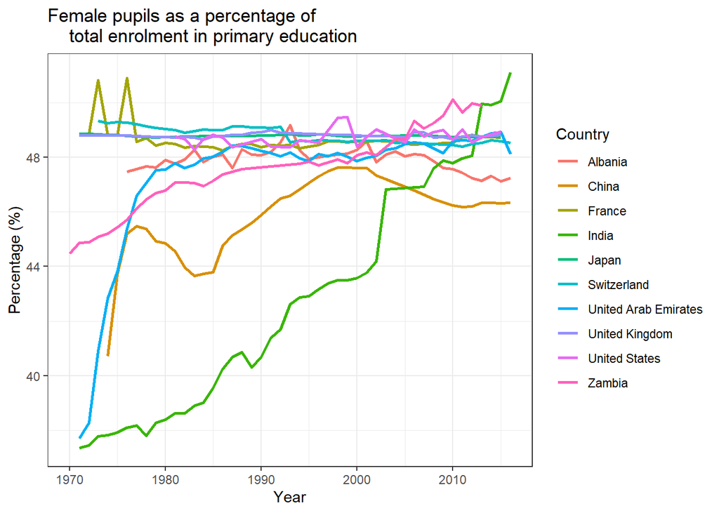

```r
ggplot(temp_data, aes(x = Year, y = PFE, color = Entity)) +
  # size = 1 sets the line thickness.
  geom_line(size = 1) +
  # Remove grey background
  theme_bw() +
  # Change the set of colours used
  scale_colour_brewer(palette = "Paired") +
  scale_colour_discrete(name = "Country") +
  # Set the vertical axis label
  ylab("Percentage (%)") +
  # Add a title
  ggtitle("Female pupils as a percentage of
    total enrolment in primary education")
```

#### Plot a column chart with sorted values

To calculate the change in the value of this measure between 1980 and 2010 for each country chosen, we have to manipulate the data so that we have one entry (row) for each entity (or country), but two different variables for the percentage of female enrolment `PFE` (one for each year).

```r
# Select all data for 1980
temp_data_80 <- subset(temp_data, Year == "1980")
# Rename variable to include year
names(temp_data_80)[4] <- "PFE_80"
# Select all data for 2010
temp_data_10 <- subset(temp_data, Year == "2010")
# Rename variable to include year
names(temp_data_10)[4] <- "PFE_10"
temp_data2 <- merge(
  temp_data_80, temp_data_10, by = c("Entity"))
```

Have a look at `temp_data2`, which now contains two variables for every country, `PFE_80` and `PFE_10`. It also has multiple variables for Year (`Year.x` and `Year.y`) and Code (`Code.x` and `Code.y`), but that is a minor issue and you could delete one of them.

Now we can calculate the difference.

```r
temp_data2$dPFE <- temp_data2$PFE_10 - temp_data2$PFE_80
```

You could plot a separate chart for each year and check the order, but here we show how to create one chart with the data from both years.

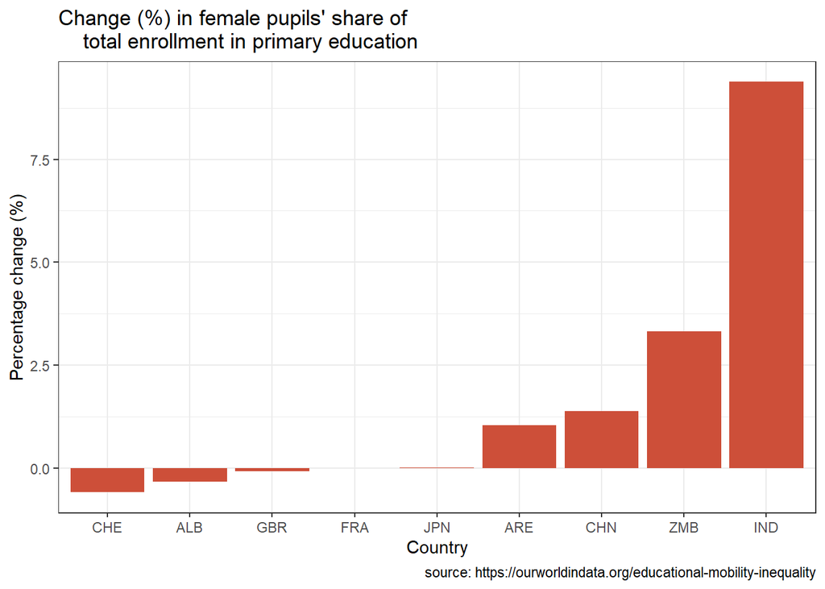

```r
ggplot(temp_data2, aes(
  x = reorder(Code.x, dPFE), y = dPFE)) +
  geom_bar(stat = "identity", fill = "tomato3") +
  labs(title = "Change (%) in female pupils' share of
    total enrollment in primary education",
    x = "Country", y = "Percentage change (%)",
    caption = "source: https://ourworldindata.org/educational-mobility-inequality") +
  theme_bw()
```

It is apparent that some countries saw very little or no change (the countries that already had very high PFE). The countries with initially low female participation have significantly improved.

[End of walk-through]

[^1]: University of Manchester’s Econometric Computing Learning Resource (ECLR). 2018. “R TSplots”. Updated 26 July 2016.